# 20260304_cei_flo_clinical_report_01 â€“ ceiling/floor report

Veru a Jirka Balounovi

Compiled on: **2026-03-05** Last updated **2026-03-09

# 1 Ceiling/Floor Clinical Report: ig_gradient pro klinickou praxi

Datum: 2026-03-05  
Autor: AI analytik (biostatistika + klinicka interpretace)

Nejprve jsem pouzil pravidlo pro aktualizaci souboru: - porovnat nazvy po odstrenani prvnich 6 znaku (datum prefix), - pokud vznikne duplikat, vzit novejsi soubor podle casu modifikace.

Hlavni aktualni zdroje: - `output/ceil_flo/tables/260303_ig_gradient_hurdle_conversion_01.xlsx` - `output/ceil_flo/tables/260303_eda_phvas_dual_kendall_01.xlsx` - `output/ceil_flo/tables/260304_disease_activity_models_01.xlsx` - `output/ceil_flo/tables/260304_phvas_ig_gradient_ceiling_models_01.xlsx` - `output/ceil_flo/tables/260305_prediction_performance_model_comparison_01.xlsx` - `output/ceil_flo/tables/260305_res_disease_model3_posthoc_all_01.xlsx` - `output/ceil_flo/tables/260305_res_disease_model3_posthoc_cei_flo_01.xlsx`

## 1.1 1. Shrnuti pro klinika (1 strana)

Cil: zhodnotit, zda lze `ig_gradient` pouzit jako praktickou nahradu klinickych skal (`mmt8`, `mmt10`, `fi2`, `fi3`, `haq`) zejmena u pacientu se stropem/dnem.

Hlavni klinicky zaver: - `ig_gradient` konzistentne pridava informaci k nekterym skalam (hlavne MMT/FI), - ale jako samostatna nahrada klinickeho parametru (`Model 3`) ve vetsine kohort nevyhrava, - nejvhodnejsi aktualni pouziti je doplnek, ne substituce.

Verdikt podle skaly:

| Skala | Verdikt | Co to znamena pro praxi |
| --- | --- | --- |
| mmt8 | Castecne | `ig_gradient` pridava signal, ale samotny klinicky parametr nelze bezpecne nahradit. |
| mmt10 | Castecne | Stejny vzorec jako mmt8, vhodny doplnek pro longitudinalni sledovani. |
| fi2 | Omezene | Dobry non-ceiling signal, ale minimum ceiling pripadu limituje robustnost. |
| fi3 | Omezene az castecne | V boundary-occurrence kohorte muze byt `ig_gradient` konkurencni, ale globalne nejde o stabilni nahradu. |
| haq | Spise ne | `ig_gradient` je slabsi a v Modelu 2 casto bez signifikance. |

## 1.2 2. Klinicky problem

Strop/dno efekt snizuje citlivost skal: - u MMT/FI pri stropech nelze dobre zachytit dalsi zlepseni, - u HAQ pri floor (0) nelze dobre zachytit dalsi zlepseni.

`ig_gradient` je prubezna, objektivni metrika aktivity a muze pridat informaci tam, kde klinicka skala saturuje.

## 1.3 3. Data a kohorta

### 1.3.1 3.1 Vstupni data

- 69 pacientu
- 1435 radku v long formatu (pacient x navsteva x outcome)
- navstevy: `M0`, `M3`, `M6`, `M18`, `M30`, `M48`
- pouzite skaly: `mmt8`, `mmt10`, `fi2`, `fi3`, `haq`
- prediktor: `ig_gradient`
- anchor aktivita: `ph_vas`

Definice hranic: - `mmt8`: strop 80 - `mmt10`: strop 100 - `fi2`: strop 100 - `fi3`: strop 100 - `haq`: floor 0 (rozsah 0-3)

### 1.3.2 3.2 Velikost analyzovanych kohort (disease activity modely)

All cohort:

| Outcome | n mereni | n pacientu |
| --- | --- | --- |
| mmt8 | 178 | 60 |
| mmt10 | 169 | 59 |
| fi2 | 155 | 57 |
| fi3 | 166 | 59 |
| haq | 179 | 60 |

No ceiling/floor cohort:

| Outcome | n mereni | n pacientu |
| --- | --- | --- |
| mmt8 | 131 | 53 |
| mmt10 | 130 | 54 |
| fi2 | 150 | 55 |
| fi3 | 148 | 55 |
| haq | 136 | 52 |

Ceiling/floor cohort (podskupina s boundary historii):

| Outcome | n mereni | n pacientu |
| --- | --- | --- |
| mmt8 | 47 | 23 |
| mmt10 | 41 | 21 |
| fi2 | 3 | 1 |
| fi3 | 13 | 6 |
| haq | 27 | 16 |

## 1.4 4. Analyticky plan

- EDA a Kendall korelace (`ig_gradient`, klinicke skaly, `ph_vas`).
- Conversion model (`ig_gradient -> klinicka skala`) s hurdle pristupem a OOF validaci.
- Disease activity modely:
  - Model 1: `ph_vas ~ clin + exam + covariates + (1|patient)`
  - Model 2: `ph_vas ~ clin + ig_gradient + exam + covariates + (1|patient)`
  - Model 3: `ph_vas ~ ig_gradient + exam + covariates + (1|patient)`
- Prediction-performance porovnani modelu napric 4 kohortami + bootstrap CI (RMSE/MAE).

## 1.5 5. Vysledky podle klinicke otazky

### 1.5.1 5.1 Jak velky je problem stropu/dna?

Boundary prevalence v OOF conversion analyze:

| Outcome | Typ hranice | Prevalence | n boundary / n total |
| --- | --- | --- | --- |
| mmt8 | ceiling | 28.0% | 58 / 207 |
| mmt10 | ceiling | 25.3% | 50 / 198 |
| fi2 | ceiling | 2.7% | 5 / 182 |
| fi3 | ceiling | 11.2% | 22 / 197 |
| haq | floor | 23.8% | 50 / 210 |

Klinicky: nejvetsi saturace je u `mmt8`, `mmt10` a `haq`.

### 1.5.2 5.2 Ma `ig_gradient` informaci mimo strop/dno?

Kendall tau (non-boundary cast, smer `ig_gradient`):

| Outcome | n | Kendall tau | p-hodnota | Delta P90-P10 (95% CI) |
| --- | --- | --- | --- | --- |
| mmt8 | 149 | 0.229 | 0.000050 | +5.93 (2.88; 9.30) |
| mmt10 | 148 | 0.263 | 0.000003 | +9.51 (5.73; 13.46) |
| fi2 | 177 | 0.345 | <0.000001 | +30.26 (20.10; 41.55) |
| fi3 | 175 | 0.270 | 0.0000001 | +25.11 (16.90; 34.52) |
| haq | 160 | -0.154 | 0.00488 | -0.393 (-0.639; -0.100) |

Interpretace: - mimo boundary je vztah statisticky prukazny u vsech outcome, - smer je klinicky konzistentni (vyssi `ig_gradient` = lepsi MMT/FI, nizsi HAQ).

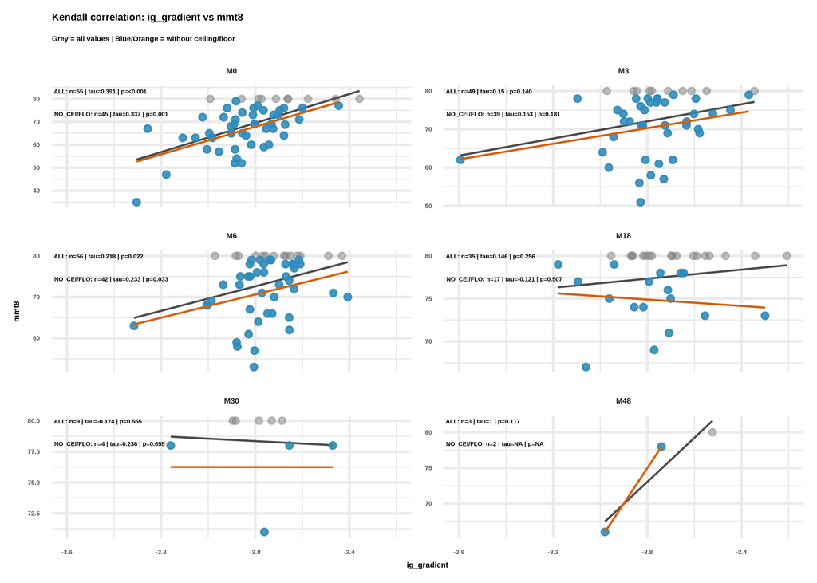

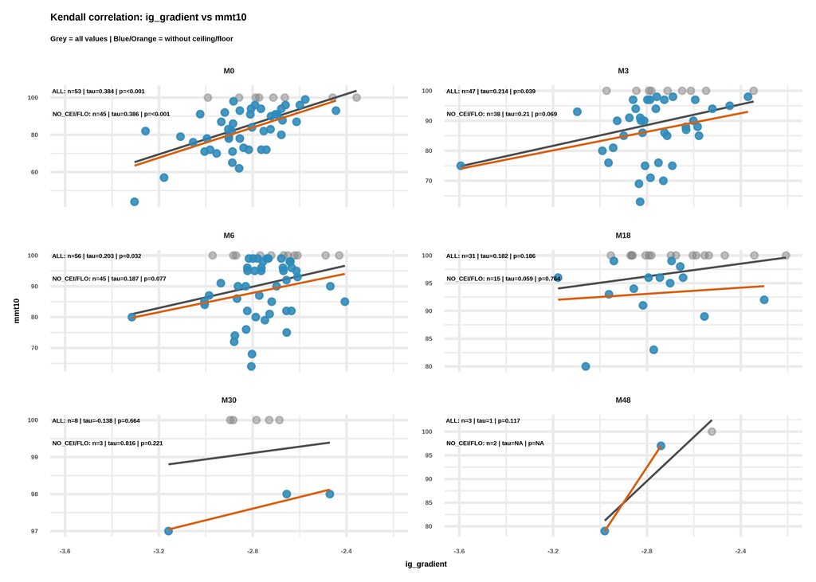

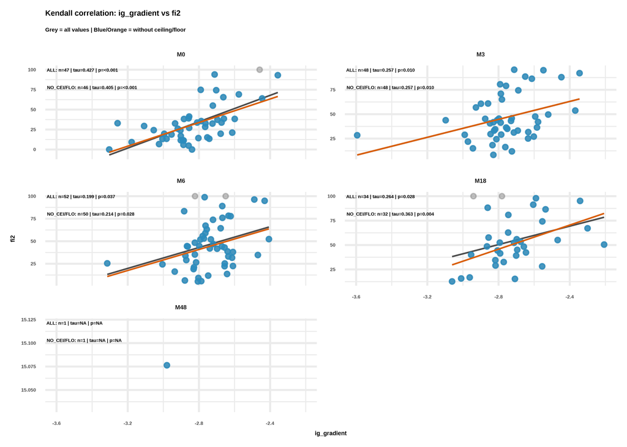

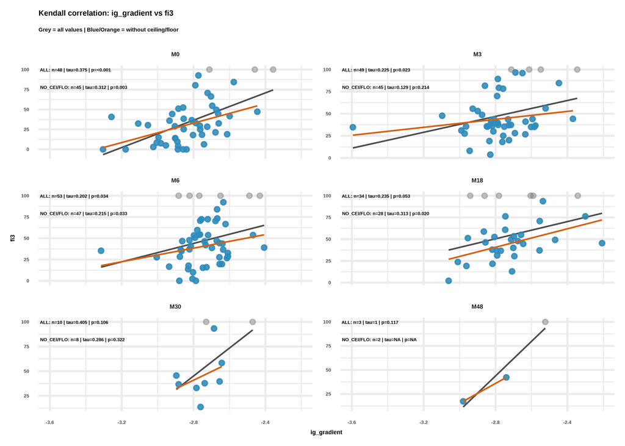

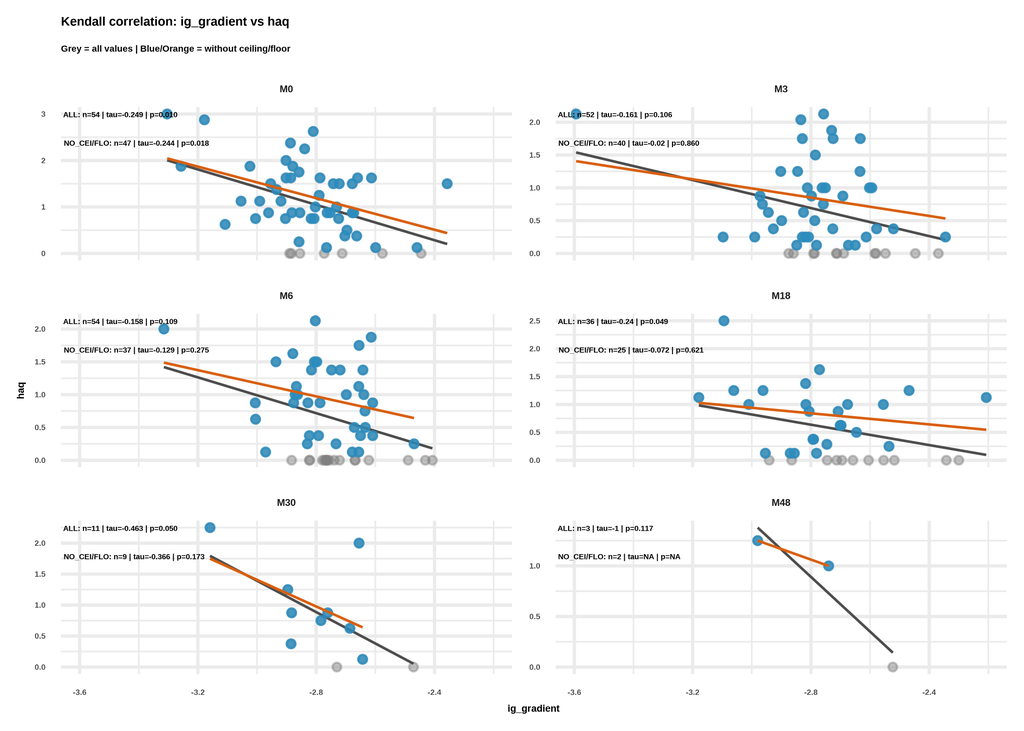

### 1.5.3 5.3 Jak se chova vztah k `ph_vas` podle exam?

Dual-axis EDA + Kendall (`ph_vas` vs `ig_gradient` a `ph_vas` vs klinicky parametr) ukazuje: - nejsilnejsi a nejstabilnejsi signal je na baseline `M0`, - pozdeji je vztah slabsi a variabilnejsi (mensi n, vice heterogenity), - `ph_vas` vs klinicky parametr ma na `M0` obecne silnejsi tau nez `ph_vas` vs `ig_gradient`.

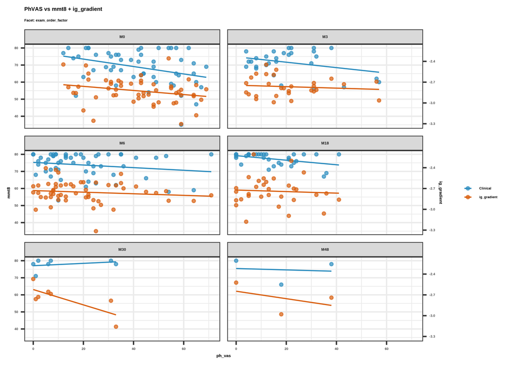

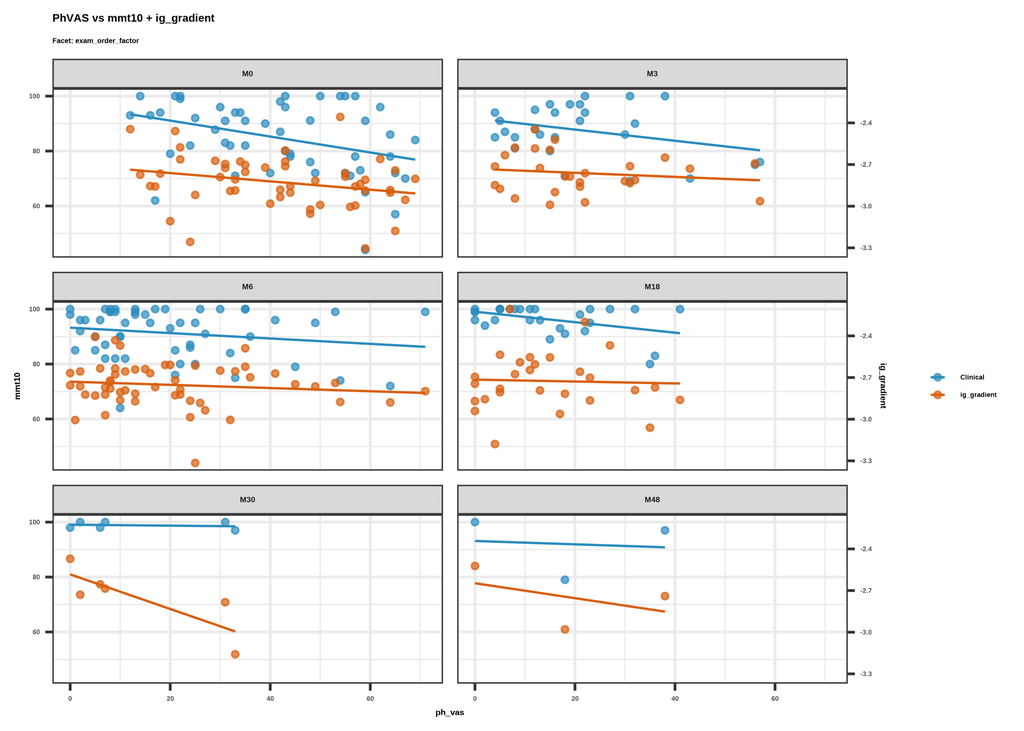

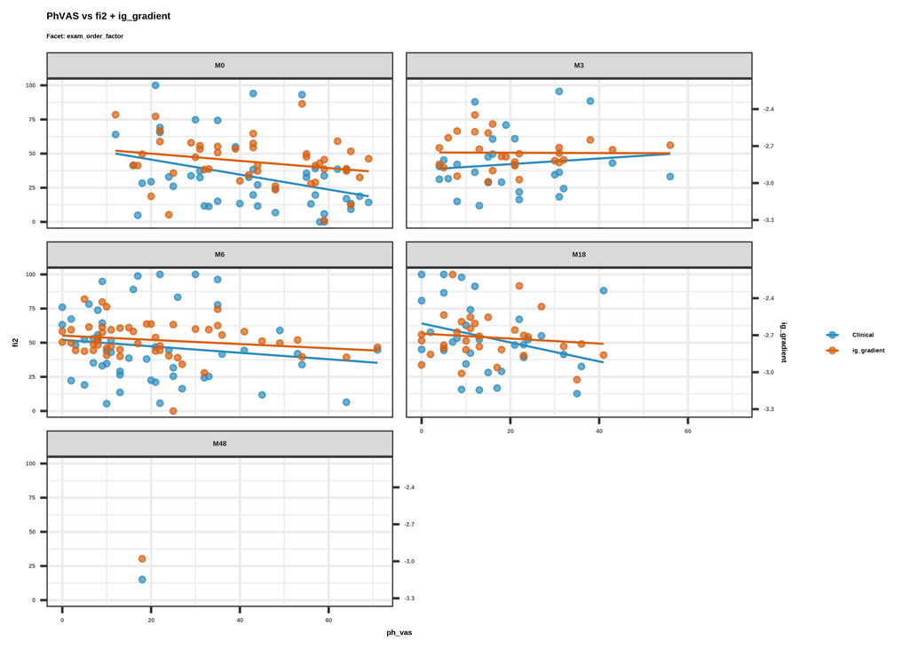

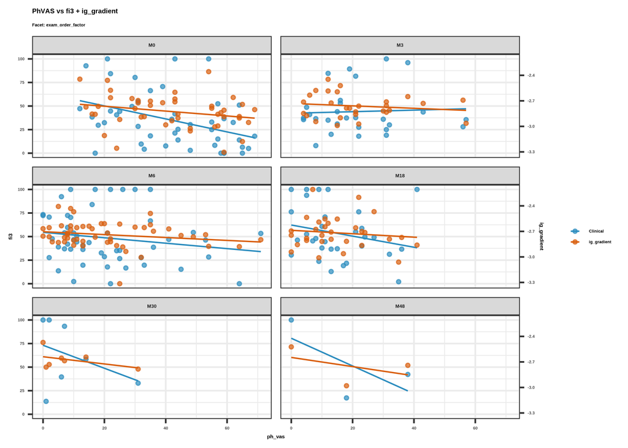

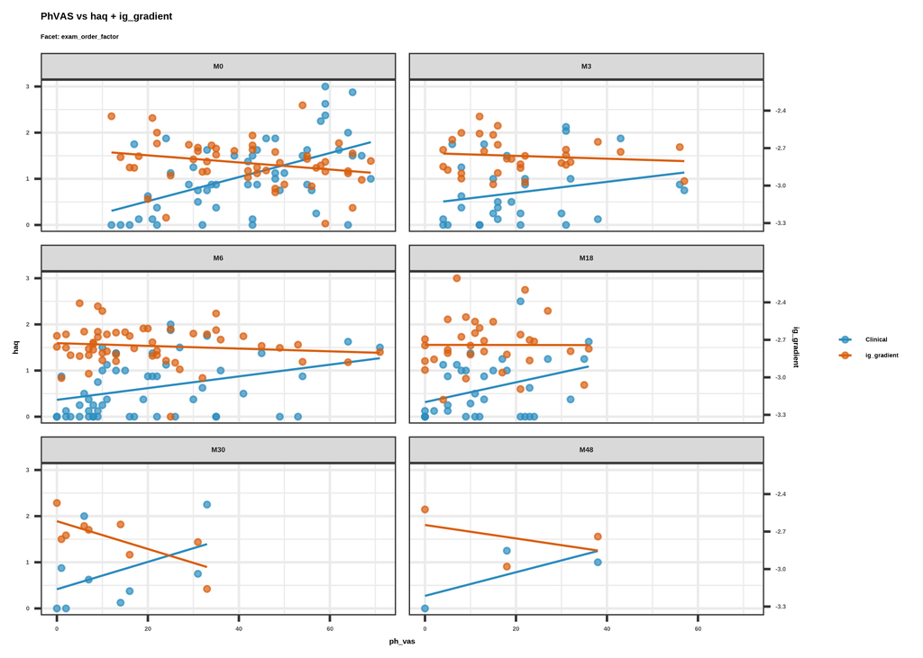

### 1.5.4 5.4 Dokaze `ig_gradient` predikovat klinickou skalu?

OOF global metriky conversion modelu:

| Outcome | MAE | RMSE | R2 |
| --- | --- | --- | --- |
| mmt8 | 5.63 | 7.22 | 0.198 |
| mmt10 | 7.50 | 9.45 | 0.217 |
| fi2 | 19.27 | 23.67 | 0.183 |
| fi3 | 21.64 | 26.28 | 0.157 |
| haq | 0.562 | 0.679 | 0.063 |

Boundary klasifikace (AUC / PR-AUC): - `mmt8`: 0.668 / 0.429 - `mmt10`: 0.666 / 0.399 - `fi2`: 0.227 / 0.022 (slabe) - `fi3`: 0.662 / 0.240 - `haq`: 0.617 / 0.333

BA-like trend chyby (`diff ~ mean`) ukazuje proporcionalni bias u vsech outcome (`trend_slope` cca 0.84 az 1.19, vsechny p << 0.001).

Decision sheet (usability): - `mmt8`, `mmt10`: `partially_usable` - `fi2`, `fi3`, `haq`: `limited`

### 1.5.5 5.5 Disease activity modely (`ph_vas`) a post-hoc

Model 2 (`clin + ig_gradient`) vs Model 1 (`clin`) : - All cohort: Model 2 vychazi nejlepe pro `mmt8`, `mmt10`, `fi2`, `fi3`; u `haq` je vyhoda modelu 1/2 prakticky remiza. - No ceiling/floor cohort: stejny vzorec, ale u `haq` je lepsi Model 1.

Fixni efekt `ig_gradient` v Modelu 2: - signifikantni pro `mmt8`, `mmt10`, `fi2`, `fi3` (all i no-cei/flo), - nesignifikantni pro `haq` (all p=0.147; no-cei/flo p=0.239).

Post-hoc Model 3 (all cohort; nove kontrasty `M0-M3`, `M0-M6`, `M0-M18`): - vsechny tri kontrasty jsou signifikantni u vsech outcome (`mmt8`, `mmt10`, `fi2`, `fi3`, `haq`), - vsechny odhady jsou zaporne (tj. proti `M0` je odhad na pozdejsich navstevach nizsi), - velikost efektu je konzistentne nejvetsi pro `M0-M18` (priblizne -26 az -27 napric outcome; p << 0.001).

Post-hoc Model 3 (ceiling/floor cohort; stejne kontrasty): - `mmt8`: signifikantni `M0-M3`, `M0-M6`, `M0-M18`  
(napr. `M0-M18`: estimate -26.5; 95% CI -36.7 az -16.4; p=3.06e-07), - `mmt10`: signifikantni `M0-M3`, `M0-M6`, `M0-M18`  
(napr. `M0-M18`: estimate -13.9; 95% CI -25.1 az -2.79; p=0.0143), - `haq`: signifikantni `M0-M3`, `M0-M6`, `M0-M18`  
(napr. `M0-M6`: estimate -43.9; 95% CI -54.1 az -33.8; p=3.01e-17), - `fi2`, `fi3`: post-hoc v teto kohorte nelze robustne odhadnout (NA; velmi maly vzorek).

Strict ceiling-only model (`ph_vas ~ ig_gradient + covariates`): - `mmt8`: beta -10.9, p=0.48 - `mmt10`: beta -13.6, p=0.25 - `fi2`, `fi3`: insufficient data

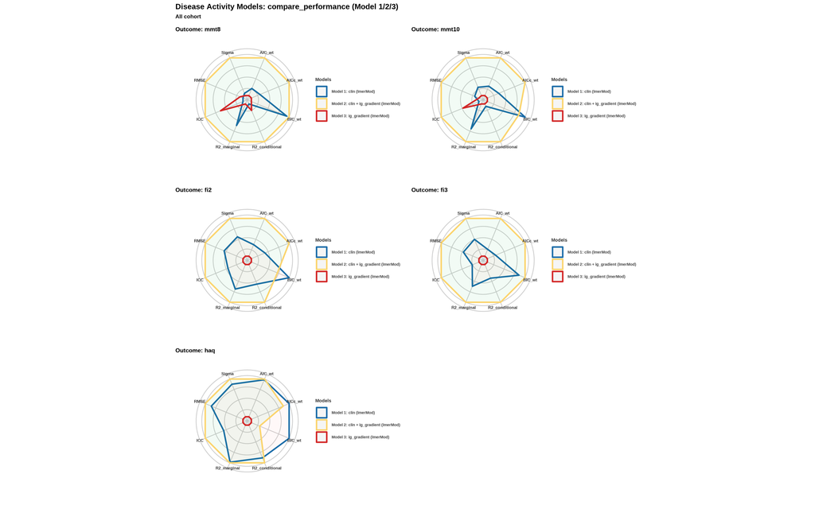

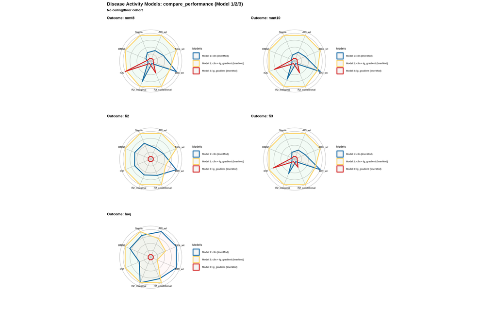

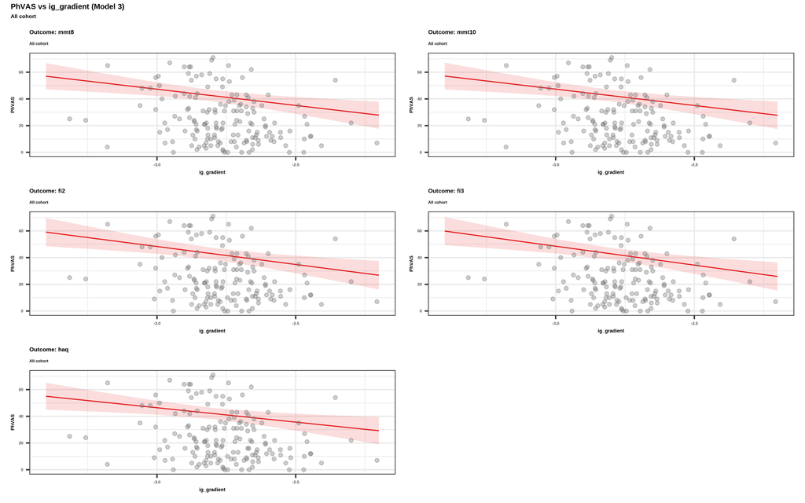

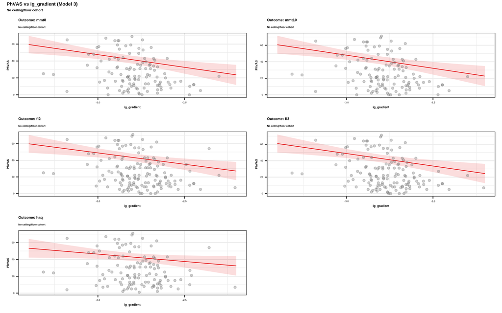

### 1.5.6 5.6 Prediction performance - model comparison (nova cast)

Porovnani podle RMSE (soubor `260305_prediction_performance_model_comparison_01.xlsx`):

| Kohorta | Co nejcasteji vyhrava | Klinicka interpretace |
| --- | --- | --- |
| No ceiling/floor cohort | Model 1 (`clin`) | V ciste non-boundary casti klinicky parametr sam o sobe funguje nejlip. |
| All cohort | Prevazne Model 2 (`clin + ig_gradient`) | `ig_gradient` pridava inkrementalni informaci. |
| Ceiling/floor only | Bez robustnich modelu | Data nedostatecna (0 validnich modelu). |
| Ceiling/floor occurrence | Prevazne Model 2, vyjimka `fi3` kde vyhral Model 3 | Nahrada jen `ig_gradient` neni stabilni napric outcome. |

Primo k otazce nahrady kliniky: - `Model 3 (ig_gradient)` **neni konzistentne nejlepsi**. - Tam, kde je prinos, je typicky ve forme **Modelu 2 (clin + ig_gradient)**. - Z biostatistickeho i klinickeho pohledu tedy plati: `ig_gradient` je vhodny **doplnek**, ne obecna nahrada.

Bootstrap 95% CI (RMSE/MAE) ukazuji velke prekryvy mezi Model 1 a 2 u casti outcome, ale Model 3 je casto horsi (hlavne `haq`, `mmt10`, `mmt8` v all cohort).

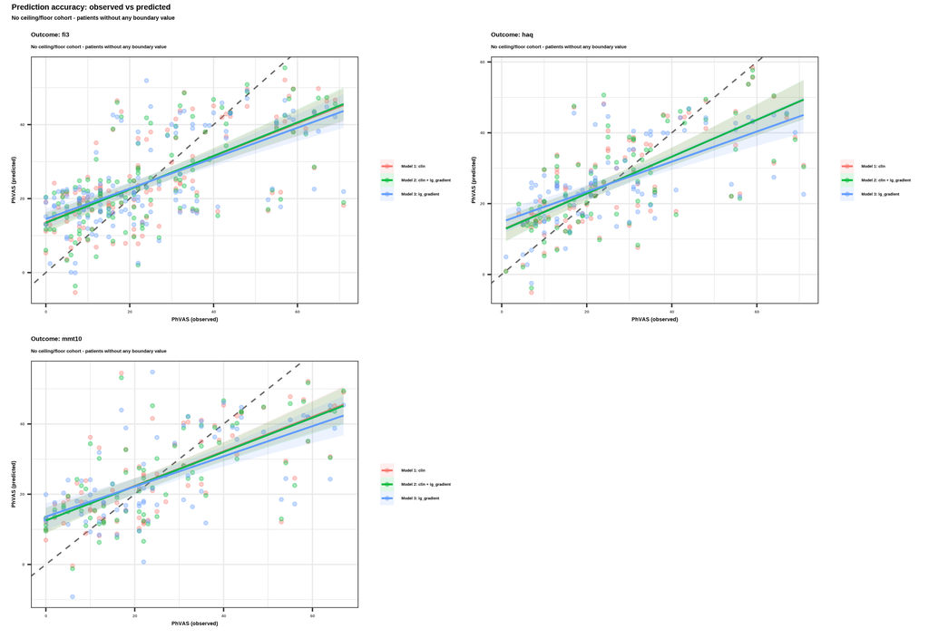

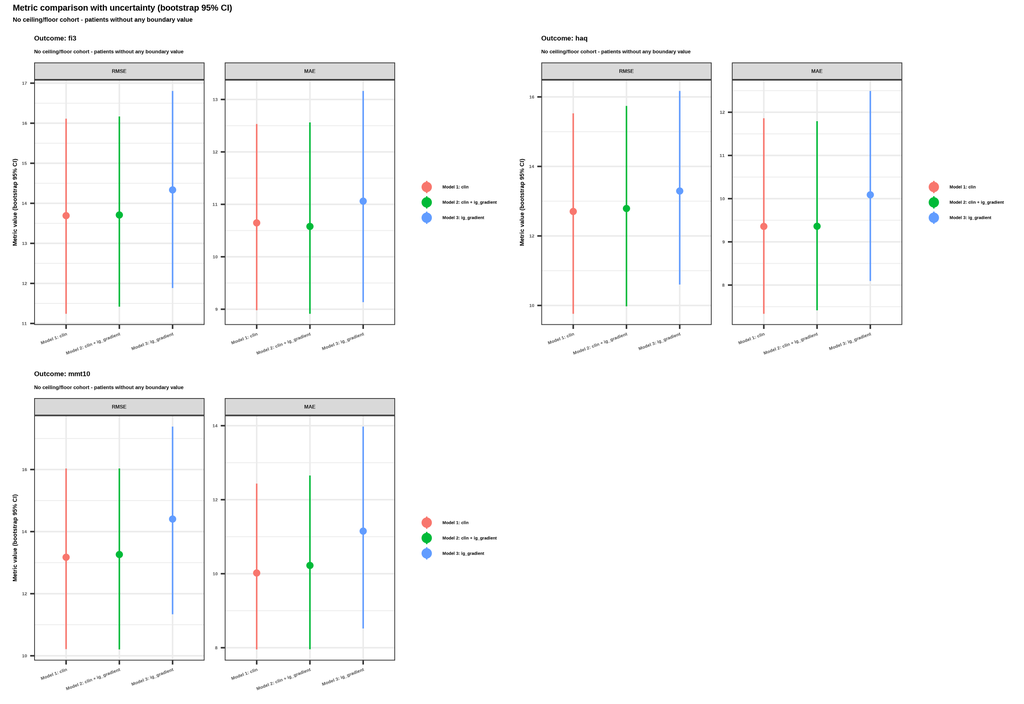

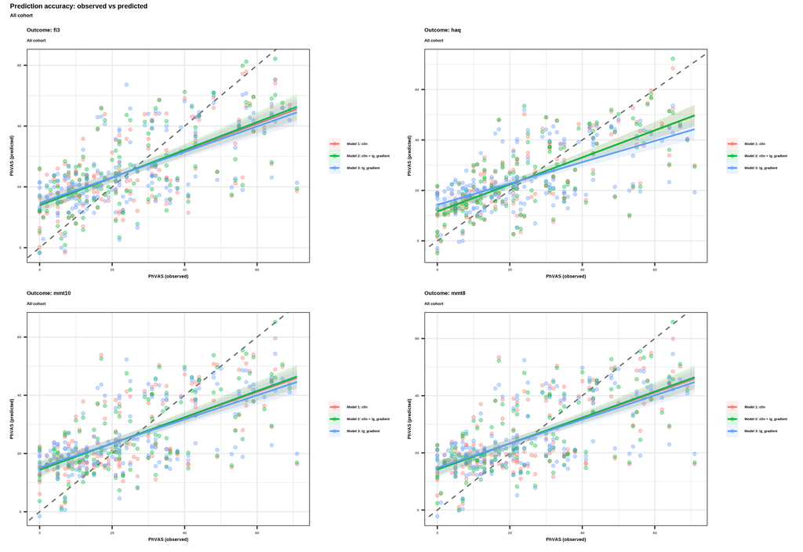

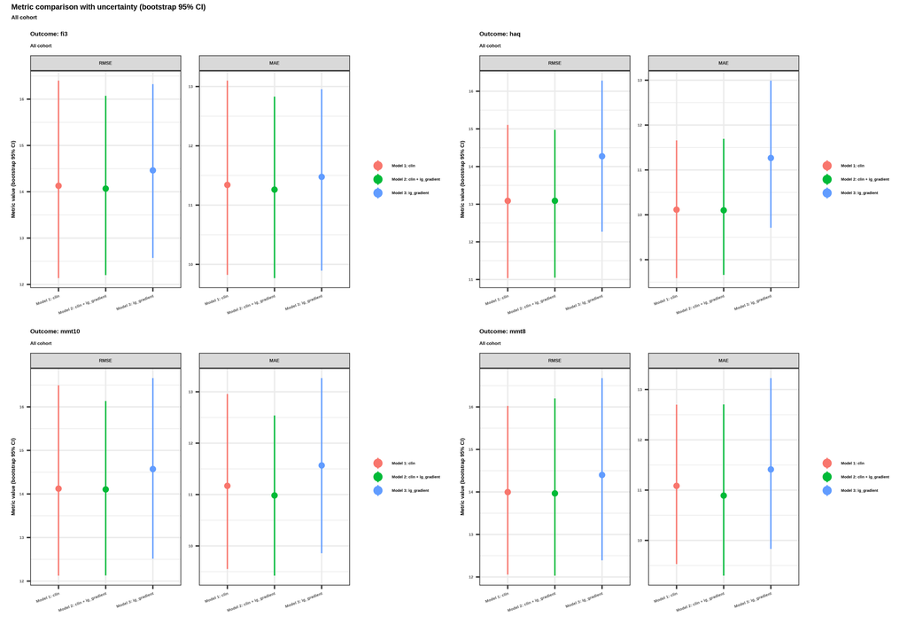

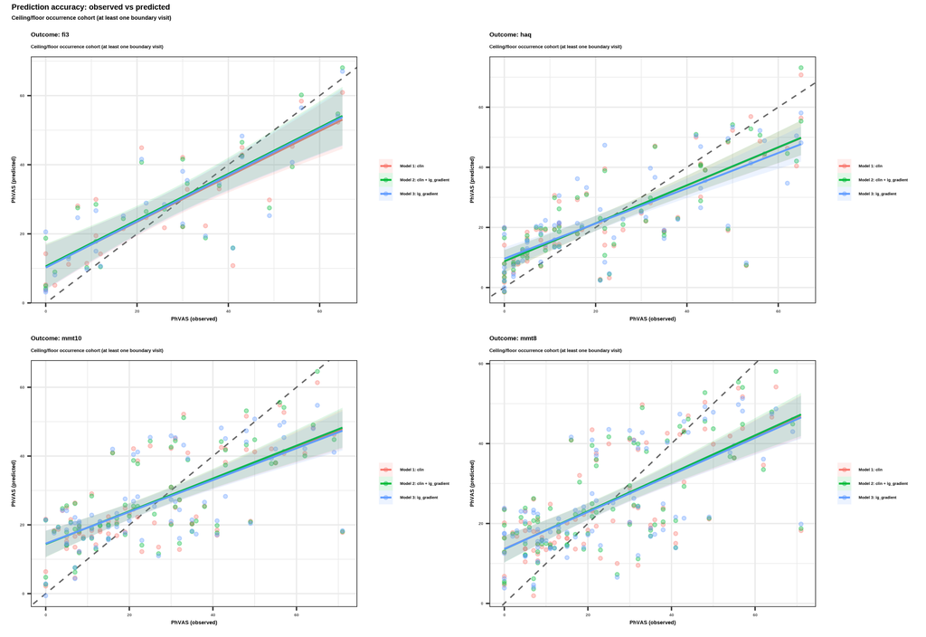

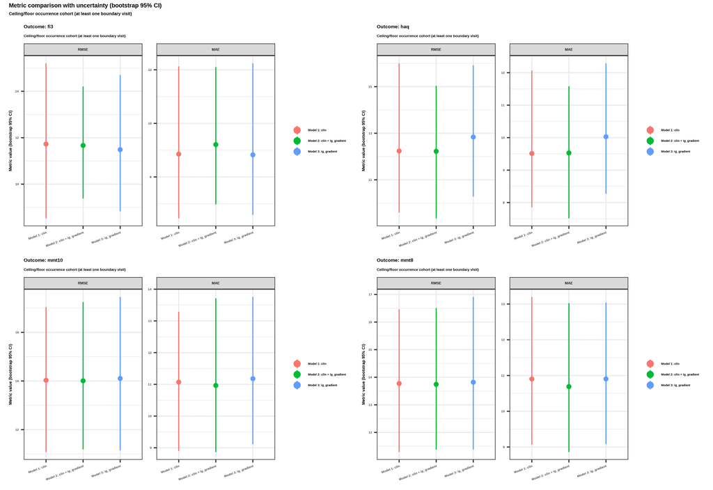

## 1.6 6. Rozhodovaci tabulka pro praxi

| Skala | Mira stropu/dna | Signal `ig_gradient` mimo boundary | Vyhra modelu | Lze nahradit klinicky parametr? | Doporuceni |
| --- | --- | --- | --- | --- | --- |
| mmt8 | Vysoka (28%) | Ano (tau 0.229) | Casto Model 2 | Ne | Drzet kliniku + pridat `ig_gradient` pro doplneni trendu. |
| mmt10 | Vysoka (25%) | Ano (tau 0.263) | Casto Model 2 | Ne | Stejne jako mmt8. |
| fi2 | Nizka (2.7%) | Ano (tau 0.345) | Model 2, ale malo boundary dat | Ne (zatim) | Potreba vice ceiling pripadu. |
| fi3 | Stredni (11.2%) | Ano (tau 0.270) | Casto Model 2, nekdy Model 3 | Spise ne | Potencial v subskupinach, ale ne globalni nahrada. |
| haq | Vysoka floor (23.8%) | Slabsi (tau -0.154) | Model 1/2 remiza, Model 3 horsi | Ne | Klinicka skala zustava primarni. |

## 1.7 7. Co delat v ordinaci

1. Primarne rozhodovat dle klinicke skaly.
2. U strop/floor pacientu pridat trend `ig_gradient` mezi navstevami.
3. Pokud je klinika stabilni, ale `ig_gradient` meni trend, overit to proti `ph_vas` a klinickemu obrazu.

Prakticky: `ig_gradient` je vhodny jako early-signal a doplnkovy digitalni marker, ne jako samostatny rozhodovaci endpoint.

## 1.8 8. Omezeni a jistota zaveru

- Nektere analyzy byly generovany v ruzne dny (03.-05.03.2026), proto byla provedena deduplikace podle nazvu bez datum prefixu + vyber novejsiho souboru.
- Pozdni navstevy (hlavne `M48`) maji maly n.
- Ceiling/floor-only kohorty jsou male; u `fi2/fi3` cast analyz selhava.
- BA-like analyza ukazuje proporcionalni bias u vsech skal.

## 1.9 Hlavni klinicky zaver

V teto kohorte `ig_gradient` zatim **neni vhodny jako plna nahrada** `mmt8/mmt10/fi2/fi3/haq`.  
Nejstabilnejsi prinos je v kombinaci s klinickym parametrem (`Model 2`), tedy jako **doplnek** pro longitudinalni monitoring a pro situace se strop/floor omezenim.

# 2 Session info

**Platform**

```r
sys_info <- Sys.info()
df_session_platform <- data.frame(
  Setting = c(
    "R version",
    "Platform",
    "Running",
    "System",
    "Release",
    "Machine",
    "User",
    "Node"
  ),
  Value = c(
    R.version.string,
    R.version$platform,
    if (!is.null(R.version$running)) R.version$running else NA_character_,
    unname(sys_info["sysname"]),
    unname(sys_info["release"]),
    unname(sys_info["machine"]),
    unname(sys_info["user"]),
    unname(sys_info["nodename"])
  ),
  stringsAsFactors = FALSE
)

kbl_platform <- knitr::kable(
  df_session_platform,
  booktabs = TRUE,
  align = "l",
  caption = "(ref:Reproducibility-SessionInfo-R-environment-title)",
  caption.short = " "
)

if (requireNamespace("kableExtra", quietly = TRUE)) {
  kbl_platform <- kableExtra::kable_styling(
    kbl_platform,
    full_width = FALSE,
    latex_options = c("hold_position"),
    bootstrap_options = c("striped", "hover", "condensed", "responsive")
  )
}

kbl_platform
```

| Setting | Value |
| --- | --- |
| R version | R version 4.5.2 (2025-10-31 ucrt) |
| Platform | x86_64-w64-mingw32 |
| Running | NA |
| System | Windows |
| Release | 10 x64 |
| Machine | x86-64 |
| User | baloun |
| Node | PRA1322B |

**Used packages**

```r
if (requireNamespace("sessioninfo", quietly = TRUE)) {
  session_pkgs <- as.data.frame(sessioninfo::package_info(), stringsAsFactors = FALSE)

  if ("attached" %in% names(session_pkgs)) {
    session_pkgs <- session_pkgs[
      !is.na(session_pkgs$attached) & session_pkgs$attached,
      ,
      drop = FALSE
    ]
  }

  keep_cols <- intersect(c("package", "loadedversion", "date"), names(session_pkgs))
  session_pkgs <- session_pkgs[, keep_cols, drop = FALSE]
} else {
  session_pkgs <- data.frame(
    package = "sessioninfo (not installed)",
    loadedversion = NA_character_,
    date = NA_character_,
    stringsAsFactors = FALSE
  )
}

knitr::kable(session_pkgs, booktabs = TRUE)
```

| package | loadedversion | date |
| --- | --- | --- |